# Homework 1

# Introduction

In this study; x,y,z axis information of acceleration is given to manipulate the data and acquire location from acceleration. Then visualise the location and execute time series presentation to interpret and summarize the data in different ways.

# Step 1 (Data Preparation)

In this step, data is read and has been through some manipulations like melting, and changes in columns - rows. The reason we melt the data is that our data is very large in numbers of column. We would like to reduce it to row basis (not column basis). So melting function is utilized. It is also done that row numbers at the raw data is counted and kept in a column “v0”, which is named “instance” soonly after. First column in the raw data is kept and named as “class” to identify easily on later steps. Lastly, time column is created and added to the data, which is acquired from “v2,v3,v4….” notation by gsub function.

```r
dat1=read.csv("trainx.csv",header=FALSE,sep="")
dat2=read.csv("trainy.csv",header=FALSE,sep="")
dat3=read.csv("trainz.csv",header=FALSE,sep="")



d1=data.frame("V0"=1:896)

dt1=data.table(cbind(d1,dat1))
dt2=data.table(cbind(d1,dat2))
dt3=data.table(cbind(d1,dat3))
setnames(dt1,"V1","class")
setnames(dt1,"V0","instance")
setnames(dt2,"V1","class")
setnames(dt2,"V0","instance")
setnames(dt3,"V1","class")
setnames(dt3,"V0","instance")

dt1 = melt(dt1,id.vars=c('class','instance'))

dt1[,time:=as.numeric(gsub("\\D", "", variable))-1]  # nondigitleri sil v2,v3,v4ten, geriye 2,3,4 kalır ondan da 1 çıkar
dt1 = dt1[order(instance,time)]



dt2 = melt(dt2,id.vars=c('class','instance'))

dt2[,time:=as.numeric(gsub("\\D", "", variable))-1]  # nondigitleri sil v2,v3,v4ten, geriye 2,3,4 kalır ondan da 1 çıkar
dt2 = dt2[order(instance,time)]



dt3 = melt(dt3,id.vars=c('class','instance'))

dt3[,time:=as.numeric(gsub("\\D", "", variable))-1]  # nondigitleri sil v2,v3,v4ten, geriye 2,3,4 kalır ondan da 1 çıkar
dt3 = dt3[order(instance,time)]
```

# Step 2 (Merging and Sampling)

In this step, our single axis data is merged to see all of 3 axises (x,y,z). Moreover, sampling is carried out by classes. 1 sample is taken from each class, thereby having 8 samples of acceleration data.

```r
xy = merge(dt1,
           dt2,
           by=c("instance","class","time"))


xyz = merge(xy,
            dt3,
            by=c("instance","class","time"))

xyz=xyz[,c(1,2,5,7,9)]  # unnecessary columns are deleted

sample1=xyz[instance%in%17,]
sample2=xyz[instance%in%29,]
sample3=xyz[instance%in%27,]
sample4=xyz[instance%in%5,]
sample5=xyz[instance%in%2,]
sample6=xyz[instance%in%28,]
sample7=xyz[instance%in%7,]
sample8=xyz[instance%in%21,]
```

# Step 3 (Finding Location of XYZ)

In this step, velocities of samples are obtained by getting cumulative sum of rows of acceleration data. Furtherly, location data is also obtained by the formula of location from average speed multiplicated by time. At the end of this part, location data for 3 axises of 8 samples are obtained.

```r
func_velocity = function(dat)
{

  for (i in 2:315)
  {
    dat[i,3] = dat[i,3] + dat[i-1,3]
    dat[i,4] = dat[i,4] + dat[i-1,4]
    dat[i,5] = dat[i,5] + dat[i-1,5]
  }
  return(dat)
}

vel1=func_velocity(sample1)
vel2=func_velocity(sample2)
vel3=func_velocity(sample3)
vel4=func_velocity(sample4)
vel5=func_velocity(sample5)
vel6=func_velocity(sample6)
vel7=func_velocity(sample7)
vel8=func_velocity(sample8)

func_location = function(vel)
{
  temp = vel
  temp[1,3] = vel[1,3]/2
  temp[1,4] = vel[1,4]/2
  temp[1,5] = vel[1,5]/2
  for (i in 2:315)
  {
    temp[i,3] = temp[i-1,3] + ((vel[i,3] + vel[i-1,3]) / 2)
    temp[i,4] = temp[i-1,4] + ((vel[i,4] + vel[i-1,4]) / 2)
    temp[i,5] = temp[i-1,5] + ((vel[i,5] + vel[i-1,5]) / 2)
  }
  return(temp)
}


loc1=func_location(vel1)
loc2=func_location(vel2)
loc3=func_location(vel3)
loc4=func_location(vel4)
loc5=func_location(vel5)
loc6=func_location(vel6)
loc7=func_location(vel7)
loc8=func_location(vel8)
```

# Step 4 (Visualisation)

In this step, location data of 8 samples (each represents 1 gesture) is visualised as scatterplot3d. A 3D plot is better in this case because of the 3d nature of the data. In order to understand the time, starting and ending points of location, colors are used. Black points represent starting part of the location and then red points follows them in correlation with time. According to these information, 8 gestures are represented below:

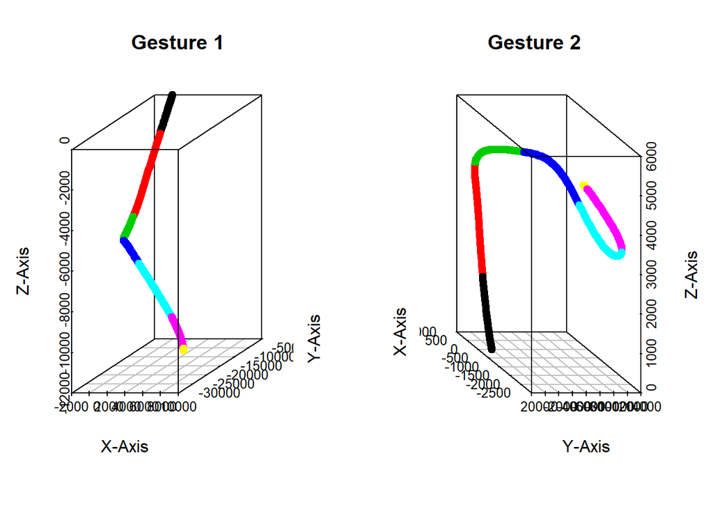

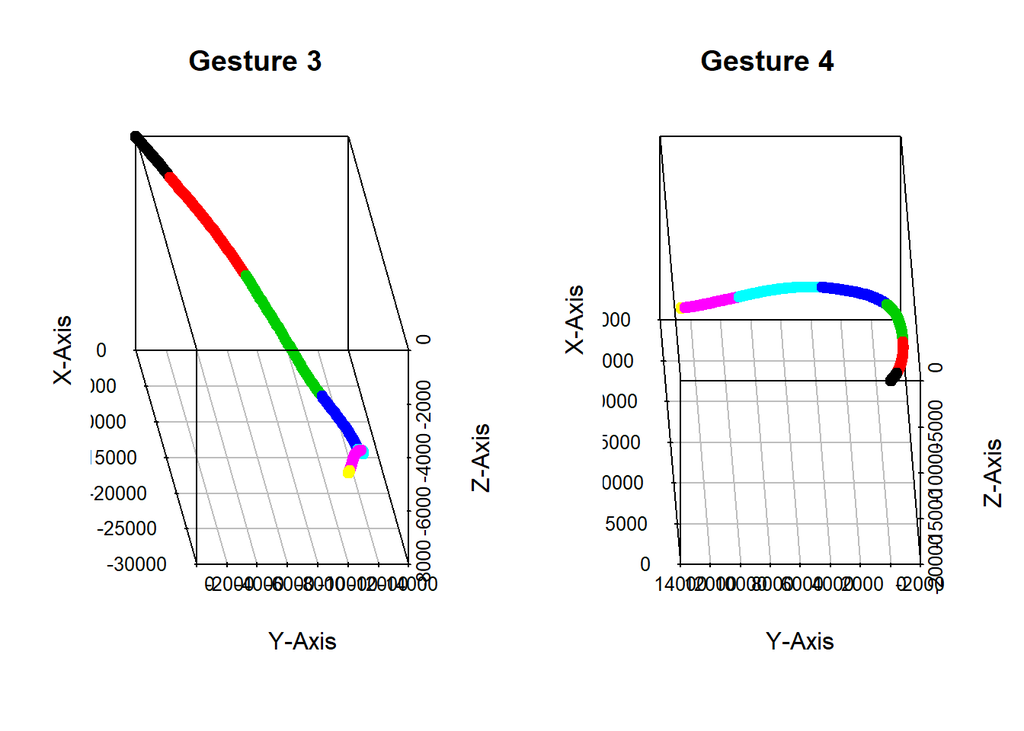

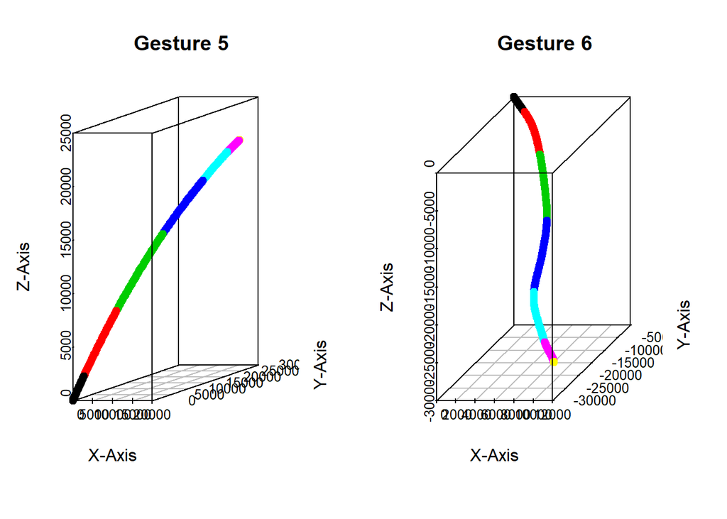

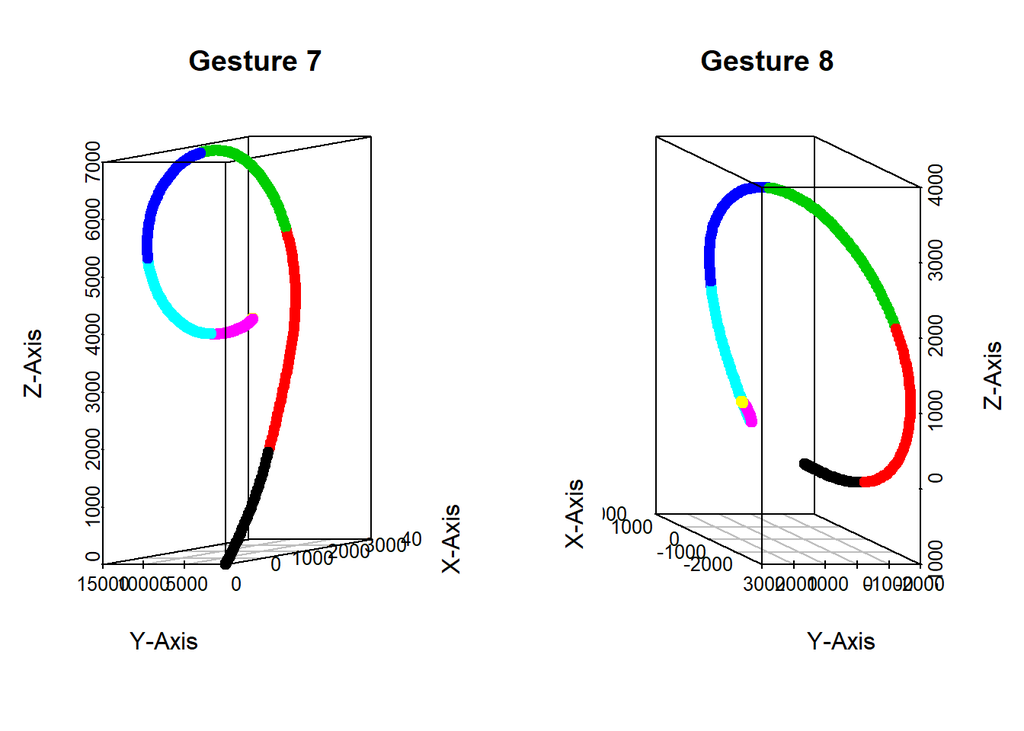

# Step 4 (Piecewise Aggregate Approximation)

In this step, time series representation of location data is done. As starting method, Piecewise Aggregate Approximation is selected to decrease compexity of the data. In this method, time series are divided into equal time segments and mean values are taken of each segment to represent the other points as well. PAA is an effective approach in this case because coordinates do not shift instantly and they can be represented by their average value. So data is divided into 9 intervals.

## Operations

Codes to operate piecewise aggregate approximation is given below:

```r
loc1[, intervals:= rep(1:9,each = 35)]
loc2[, intervals:= rep(1:9,each = 35)]
loc3[, intervals:= rep(1:9,each = 35)]
loc4[, intervals:= rep(1:9,each = 35)]
loc5[, intervals:= rep(1:9,each = 35)]
loc6[, intervals:= rep(1:9,each = 35)]
loc7[, intervals:= rep(1:9,each = 35)]
loc8[, intervals:= rep(1:9,each = 35)]


l1=cbind(loc1[,mean(value.x), by = "intervals"],loc1[,mean(value.y), by = "intervals"],loc1[,mean(value), by = "intervals"])
l2=cbind(loc2[,mean(value.x), by = "intervals"],loc2[,mean(value.y), by = "intervals"],loc2[,mean(value), by = "intervals"])
l3=cbind(loc3[,mean(value.x), by = "intervals"],loc3[,mean(value.y), by = "intervals"],loc3[,mean(value), by = "intervals"])
l4=cbind(loc4[,mean(value.x), by = "intervals"],loc4[,mean(value.y), by = "intervals"],loc4[,mean(value), by = "intervals"])
l5=cbind(loc5[,mean(value.x), by = "intervals"],loc5[,mean(value.y), by = "intervals"],loc5[,mean(value), by = "intervals"])
l6=cbind(loc6[,mean(value.x), by = "intervals"],loc6[,mean(value.y), by = "intervals"],loc6[,mean(value), by = "intervals"])
l7=cbind(loc7[,mean(value.x), by = "intervals"],loc7[,mean(value.y), by = "intervals"],loc7[,mean(value), by = "intervals"])
l8=cbind(loc8[,mean(value.x), by = "intervals"],loc8[,mean(value.y), by = "intervals"],loc8[,mean(value), by = "intervals"])

plotter=function(l,data){
  par(mfrow=c(3,2))
  ts.plot(l[,2],main="X PAA")
  ts.plot(data[,3],main="X DEFAULT")
  ts.plot(l[,4],main="Y PAA")
  ts.plot(data[,4],main="Y DEFAULT")
  ts.plot(l[,6],main="Z PAA")
  ts.plot(data[,5],main="Z DEFAULT")


  return(l)
}
```

## Visualisation

Graphs of PAA representation is given below:

### Sample 1

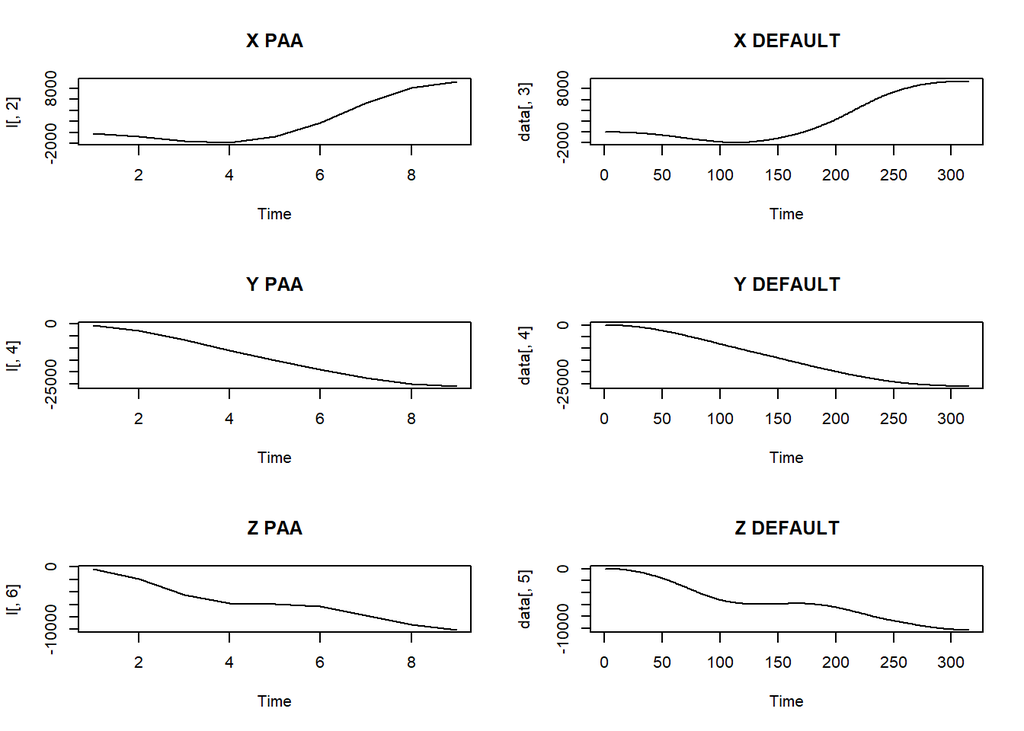

```
##    intervals          V1 intervals          V1 intervals          V1
## 1:         1   -95.76673         1   -419.8645         1   -274.7167
## 2:         2  -670.29741         2  -2769.0219         2  -1868.2741
## 3:         3 -1566.74076         3  -6605.9936         3  -4425.5963
## 4:         4 -1821.68833         4 -10842.5798         4  -5837.4759
## 5:         5  -720.57218         5 -14957.9820         5  -5878.9414
## 6:         6  1742.82851         6 -19028.9287         6  -6291.8952
## 7:         7  5356.61294         7 -22460.7714         7  -7771.6836
## 8:         8  8148.67306         8 -24817.1179         8  -9185.3299
## 9:         9  9256.36375         9 -25872.4249         9 -10094.3070
```

### Sample 2

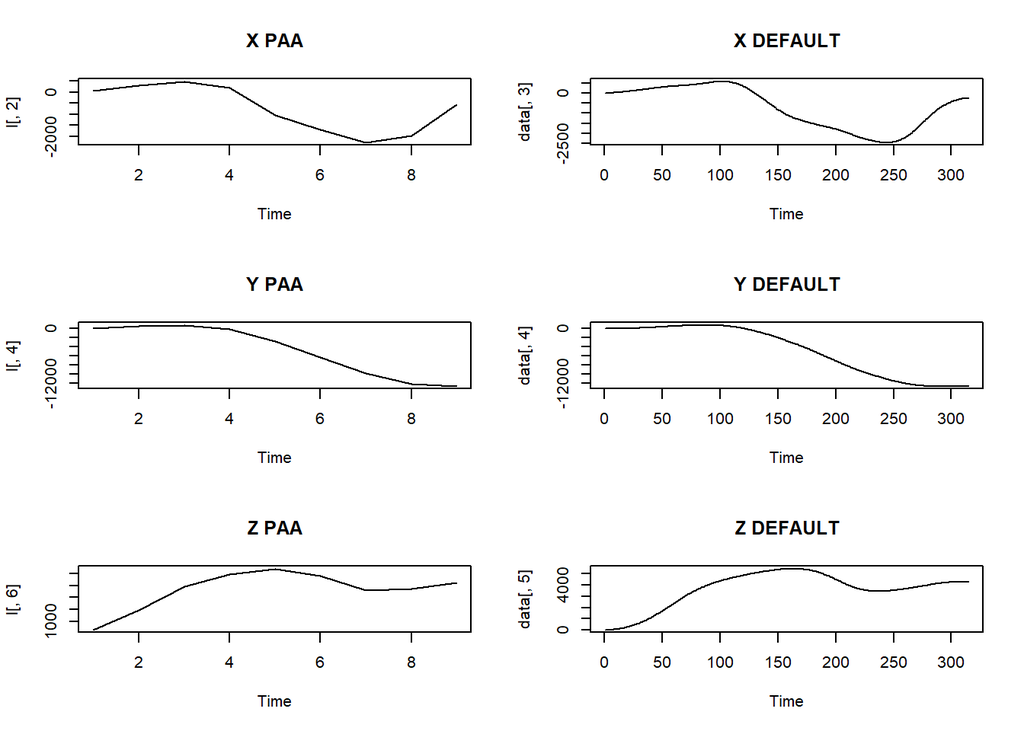

```
##    intervals          V1 intervals           V1 intervals        V1
## 1:         1    72.30599         1     78.92438         1  290.8787
## 2:         2   295.69248         2    472.67932         2 1932.8643
## 3:         3   487.71424         3    759.82186         3 3897.9680
## 4:         4   188.33337         4   -152.73035         4 4914.1033
## 5:         5 -1032.77580         5  -2711.43122         5 5391.1764
## 6:         6 -1702.27048         6  -6267.55306         6 4776.8965
## 7:         7 -2290.71118         7  -9753.62994         7 3586.5989
## 8:         8 -1986.33125         8 -12023.77418         8 3722.0881
## 9:         9  -558.73837         9 -12600.47971         9 4207.9880
```

### Sample 3

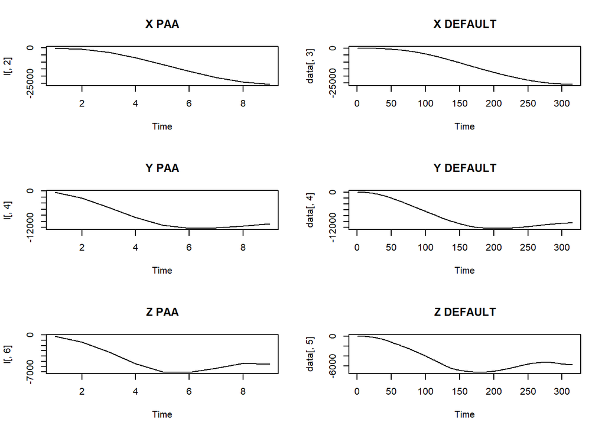

```
##    intervals          V1 intervals          V1 intervals         V1
## 1:         1   -147.0502         1   -349.1186         1  -200.2889
## 2:         2  -1031.9987         2  -2336.9910         2 -1380.8104
## 3:         3  -3178.3927         3  -5459.2837         3 -3248.2923
## 4:         4  -6946.8536         4  -8677.1237         4 -5488.8711
## 5:         5 -11687.7905         5 -11228.6848         5 -6965.2210
## 6:         6 -16488.0439         6 -12297.4907         6 -7089.4089
## 7:         7 -20750.5467         7 -12209.0908         7 -6282.2013
## 8:         8 -23982.2281         8 -11479.7872         8 -5398.1967
## 9:         9 -25672.2062         9 -10746.8800         9 -5508.9180
```

### Sample 4

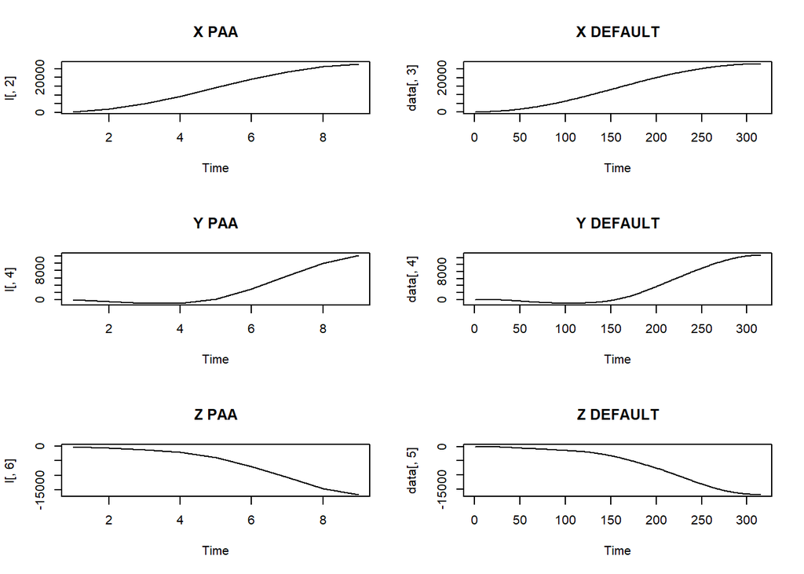

```
##    intervals         V1 intervals          V1 intervals           V1
## 1:         1   273.9601         1   -84.65406         1    -99.26259
## 2:         2  1871.8690         2  -543.50110         2   -597.23436
## 3:         3  5003.2325         3 -1025.14760         3  -1175.18963
## 4:         4  9327.5860         4  -977.35148         4  -1985.85865
## 5:         5 14222.2840         5   151.23696         5  -3882.09624
## 6:         6 19100.1035         6  2984.04998         6  -6927.06136
## 7:         7 23209.2460         7  6661.93658         7 -10705.55317
## 8:         8 26172.2249         8 10076.33191         8 -14484.84246
## 9:         9 27778.7759         9 12258.61301         9 -16630.84855
```

### Sample 5

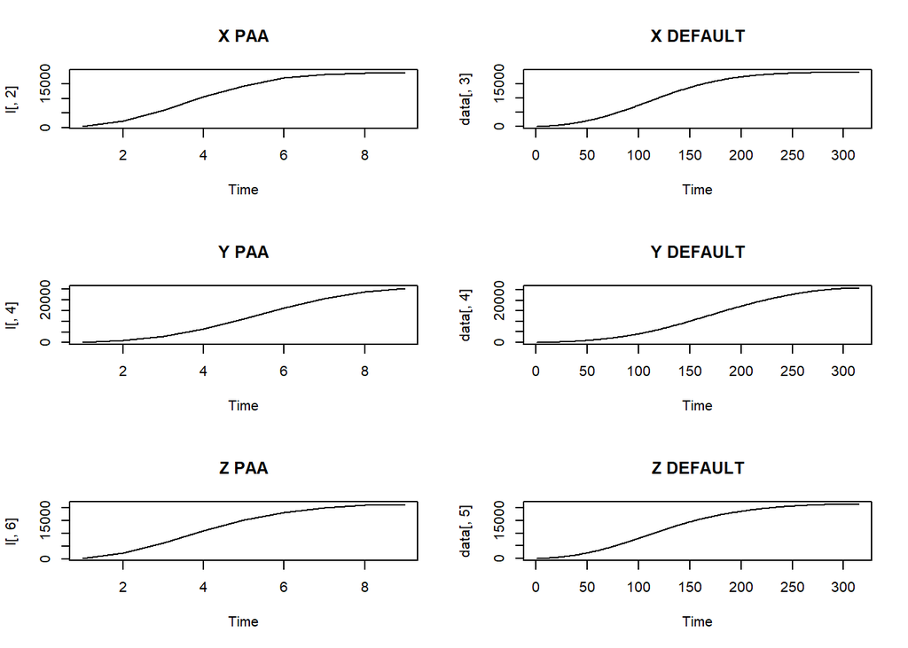

```
##    intervals         V1 intervals         V1 intervals         V1
## 1:         1   345.0681         1   143.6032         1   379.0705
## 2:         2  2278.5710         2  1063.9190         2  2500.6002
## 3:         3  5936.4690         3  3071.1293         3  6364.9616
## 4:         4 10515.4464         4  6515.2645         4 11063.2292
## 5:         5 14479.8659         5 11228.2388         5 15226.4646
## 6:         6 17070.2080         6 16215.5105         6 18132.9741
## 7:         7 18373.9583         7 20517.3516         7 19945.5925
## 8:         8 18911.3587         8 23711.9015         8 20946.9153
## 9:         9 19127.8793         9 25431.7129         9 21400.5438
```

### Sample 6

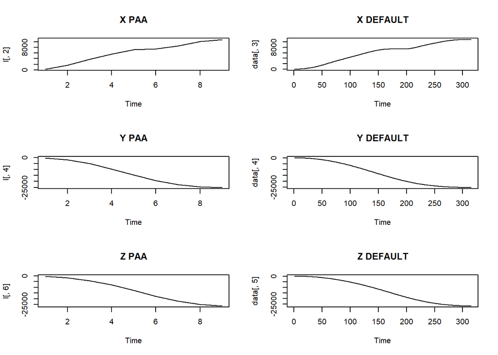

```
##    intervals         V1 intervals          V1 intervals         V1
## 1:         1   255.0132         1   -278.2714         1   -228.447
## 2:         2  1706.8347         2  -1901.5210         2  -1560.082
## 3:         3  3754.9560         3  -5101.2985         3  -4164.917
## 4:         4  5673.9180         4  -9577.2305         4  -7977.648
## 5:         5  7159.9122         5 -14600.4245         5 -12745.929
## 6:         6  7452.3893         6 -19190.3851         6 -17820.974
## 7:         7  8557.6927         7 -22481.7127         7 -22190.186
## 8:         8 10026.4123         8 -24334.2654         8 -25047.072
## 9:         9 10792.9162         9 -25113.6520         9 -26342.549
```

### Sample 7

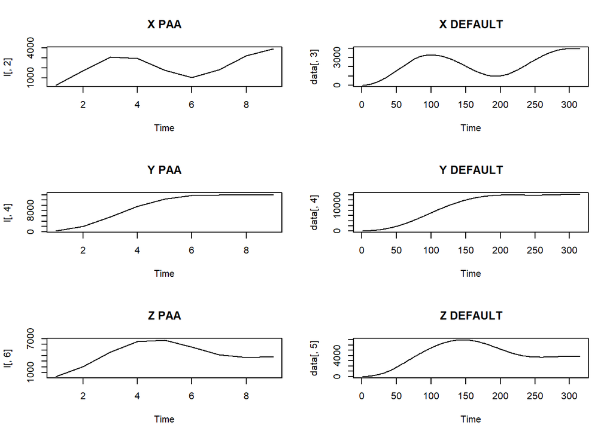

```
##    intervals        V1 intervals         V1 intervals        V1
## 1:         1  303.6054         1   281.6011         1  279.7261
## 2:         2 1733.4138         2  2095.7831         2 2035.5584
## 3:         3 3080.5308         3  5642.5757         3 4630.5135
## 4:         4 2926.9712         4  9609.5882         4 6488.0351
## 5:         5 1777.3105         5 12493.9829         5 6775.4451
## 6:         6 1044.8509         6 13808.6483         6 5553.2360
## 7:         7 1822.8417         7 13975.6474         7 4123.9069
## 8:         8 3212.9322         8 13980.5080         8 3703.8660
## 9:         9 3907.2819         9 14209.3823         9 3815.6061
```

### Sample 8

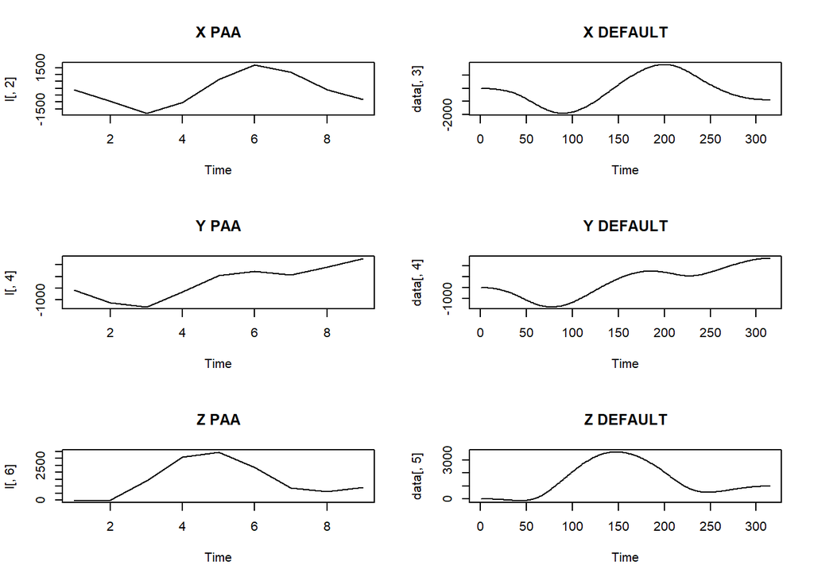

```
##    intervals         V1 intervals         V1 intervals          V1
## 1:         1  -108.4594         1  -196.0685         1  -41.376386
## 2:         2  -939.1626         2 -1253.2975         2    2.735601
## 3:         3 -1824.0286         3 -1628.7068         3 1400.434725
## 4:         4 -1022.5928         4  -346.1238         4 3119.862016
## 5:         5   655.0327         5  1060.0754         5 3474.415966
## 6:         6  1721.0744         6  1449.9896         6 2381.537565
## 7:         7  1167.9264         7  1151.4389         7  856.886907
## 8:         8  -124.8833         8  1786.1585         8  615.998758
## 9:         9  -794.5308         9  2554.4436         9  918.953518
```

## Summarize of PAA

As it is seen in the graphs above, mean graphs (paa graphs) are very close to default values of location before operating PAA. So, mean values are good representatives and each class could be represented in PAA method without losing too much information while decreasing complexity of the data.

# Step 5 (Symbolic Aggregate Approximation)

SAX method is chosen as an alternative way to PAA method. In this method, data is divided into time intervals and location position information is used to symbolize the values in specific range. Values are grouped according to the range that they are in and a character is assigned with respect to their group. Basically, function below operates this encryption and assignes a letter (“A,B,C,D,E,F,G,H,I,J,K,L”). Data is divided into 12 groups, each group has range of 5000 (like -30.000<“A”<-25.000).

```r
sax = function(l){
  temp1 = data.frame(stringsAsFactors=FALSE)

   l=as.data.frame(l)
  for (i in 1:9) {

    for (j in 1:3) {
      if ((-30000)<=as.numeric(l[i,2*j]) & as.numeric(l[i,2*j])<(-25000))
      {
        temp1[i,j] = "A"
      }
      else if ((-25000)<=as.numeric(l[i,2*j]) & as.numeric(l[i,2*j])<(-20000))
      {
        temp1[i,j] = "B"
      }
      else if ((-20000)<=as.numeric(l[i,2*j]) & as.numeric(l[i,2*j])<(-15000))
      {
        temp1[i,j] = "C"
      }
      else if ((-15000)<=as.numeric(l[i,2*j]) & as.numeric(l[i,2*j])<(-10000))
      {
        temp1[i,j] = "D"
      }

      else if ((-10000)<=as.numeric(l[i,2*j]) & as.numeric(l[i,2*j])<(-5000))
      {
        temp1[i,j] = "E"
      }
      else if ((-5000)<=as.numeric(l[i,2*j]) & as.numeric(l[i,2*j])<(0))
      {
        temp1[i,j] = "F"
      }
      else if ((0)<=as.numeric(l[i,2*j]) & as.numeric(l[i,2*j])<(5000))
      {
        temp1[i,j] = "G"
      }
      else if ((5000)<=as.numeric(l[i,2*j]) & as.numeric(l[i,2*j])<(10000))
      {
        temp1[i,j] = "H"
      }
      else if ((10000)<=as.numeric(l[i,2*j]) & as.numeric(l[i,2*j])<(15000))
      {
        temp1[i,j] = "I"
      }
      else if ((15000)<=as.numeric(l[i,2*j]) & as.numeric(l[i,2*j])<(20000))
      {
        temp1[i,j] = "J"
      }
      else if ((20000)<=as.numeric(l[i,2*j]) & as.numeric(l[i,2*j])<(25000))
      {
        temp1[i,j] = "K"
      }
      else if ((25000)<=as.numeric(l[i,2*j]) & as.numeric(l[i,2*j])<(30000))
      {
        temp1[i,j] = "L"
      }

    }
  }
  colnames(temp1)=c("X","Y","Z")
  return(temp1)
}
```

## Visualisation of SAX

Code below shows represented version of location data for each of 8 samples (gestures).

```r
print(sax(l1))
```

```
##   X Y Z
## 1 F F F
## 2 F F F
## 3 F E F
## 4 F D E
## 5 F D E
## 6 G C E
## 7 H B E
## 8 H B E
## 9 H A D
```

```r
  print(sax(l2))
```

```
##   X Y Z
## 1 G G G
## 2 G G G
## 3 G G G
## 4 G F G
## 5 F F H
## 6 F E G
## 7 F E G
## 8 F D G
## 9 F D G
```

```r
  print(sax(l3))
```

```
##   X Y Z
## 1 F F F
## 2 F F F
## 3 F E F
## 4 E E E
## 5 D D E
## 6 C D E
## 7 B D E
## 8 B D E
## 9 A D E
```

```r
  print(sax(l4))
```

```
##   X Y Z
## 1 G F F
## 2 G F F
## 3 H F F
## 4 H F F
## 5 I G F
## 6 J G E
## 7 K H D
## 8 L I D
## 9 L I C
```

```r
  print(sax(l5))
```

```
##   X Y Z
## 1 G G G
## 2 G G G
## 3 H G H
## 4 I H I
## 5 I I J
## 6 J J J
## 7 J K J
## 8 J K K
## 9 J L K
```

```r
  print(sax(l6))
```

```
##   X Y Z
## 1 G F F
## 2 G F F
## 3 G E F
## 4 H E E
## 5 H D D
## 6 H C C
## 7 H B B
## 8 I B A
## 9 I A A
```

```r
  print(sax(l7))
```

```
##   X Y Z
## 1 G G G
## 2 G G G
## 3 G H G
## 4 G H H
## 5 G I H
## 6 G I H
## 7 G I G
## 8 G I G
## 9 G I G
```

```r
  print(sax(l8))
```

```
##   X Y Z
## 1 F F F
## 2 F F G
## 3 F F G
## 4 F F G
## 5 G G G
## 6 G G G
## 7 G G G
## 8 F G G
## 9 F G G
```

# Conclusion

To conclude, PAA is a very effective method because it is more capable of recognizing gestures due to the small changes in the values. However, time interval must be chosen appropriately to use PAA efficiently. Moreover, SAX is also a good alternative representation technique due to the fact that SAX makes data less complex to read and less confusing thanks to letter notation but it may be misleading if value ranges of groups are identified inaccurate.